# Practical ggplot2

## Introduction

This practical exercise builds upon existing ggplot2 resources.

The **first part** of the notebook will walk you through the the different elements that make up a plot and highlight tips that will help with practical code implementation of ggplot2. It is a condensed version of an online workshop delivered by a member of the Tidyverse team, Thomas Lin Pedersen, which can be viewed on [YouTube](https://www.youtube.com/watch?v=h29g21z0a68).

The **second part** of the notebook provides a practical framework to develop a consistent design style for yourself or your organisation.

## Part 1: The grammar of graphics

ggplot2 is an implementation of the theoretical framework for constructing data visualisations known as the Grammar of Graphics.

Rather than thinking of data visualisations as entirely separate entities, e.g., box plot, line chart, bar chart, scatter plot, the Grammar of Graphics breaks all data visualisations into eight constituent parts, which are layered on top of each other. The theory explains the relationships between these eight parts:

- theme
- coordinates
- facets
- geometries
- scales
- statistics
- mapping
- data

This approach means you are not limited to a set of predefined data visualisations. You can build plots from the bottom up, and tailor them however you prefer.

In the sections below we will use the Grammar of Graphics framework to explore how to create plots with ggplot2.

### Dependencies and data sets

This document comes with a list of required libraries: *‘ggplot2’* and *‘dplyr’*. We will use two of the build-in data sets *‘diamonds’* and *‘iris’*.

### The grammar of graphics: Data

##### **DATA** / mapping / statistics / scales / geometries / facets / coordinates / theme

- `ggplot()` initialises a ggplot object
- It can be used to declare:
  - the input data frame *(**data**)*
  - plot aesthetics *(**mapping**)*
- The data should be a tidy data frame format
- Use `+` to combine ggplot2 elements
- Adding a geometry creates a plot *(**geometries**)*

```r
# Data 1
# Data can be added to ggplot(). If set here the data and mapping values will be inherited by subsequent layers.
ggplot(data = iris,
       mapping = aes(x = Sepal.Length, y = Petal.Length)) +
  geom_point()
```

```r
# Data 2
# Another method is to set data in the ggplot() element and the mapping in the geom layer.
ggplot(data = iris) +
 geom_point(mapping = aes(Sepal.Length, Petal.Length))
```

```r
# Data 3
# You can also set both the data and the mapping at the geom layer
ggplot() +
  geom_point(data = iris, mapping = aes(x = Sepal.Length, y = Petal.Length))
```

```r
# Data 4
# It is common for the arguments not be used
ggplot(iris) +
 geom_point(aes(x = Sepal.Length, y = Petal.Length))
```

[output not shown]

> *Note:* to create the plot in the example above you only needed to:  
> - Specify which **data** to use  
> - Select the aesthetic **mappings**  
> - Select a **geometry**  
> This is because there are a lot of sensible defaults written into the ggplot2 package that handles the other elements of the plot.

### The grammar of graphics: Mapping

##### data / **MAPPING** / statistics / scales / geometries / facets / coordinates / theme

- Aesthetic mappings link variables in the data to graphical properties in the geometries.
- They inform the graphics of which variables should be prepresented by the x and y-axes, whether a variable should be represented by a colour, size or shape etc.
- Different geoms have different mapping requirements (e.g., `geom_point()` requires `x` and `y` values and `geom_histogram()` only requires `x` values). If you are unsure of a geom’s mapping requirements you can check the ‘Aesthetics’ section of the help documentation (e.g., `?geom_point`).

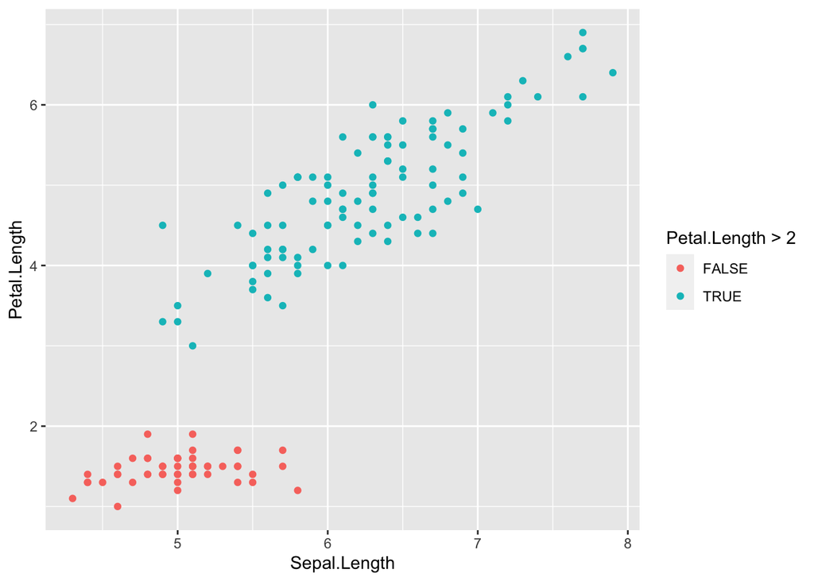

```r
# Mapping 1
# You can map colour to your data using the colour aesthetic.
# We can use an expression to map the colour, as the x and y values are not passed in as strings. Note that a legend is created when you map a variable to colour.
ggplot(data = iris) +
 geom_point(mapping = aes(x = Sepal.Length,
                          y = Petal.Length,
                          colour = Petal.Length >2))
```

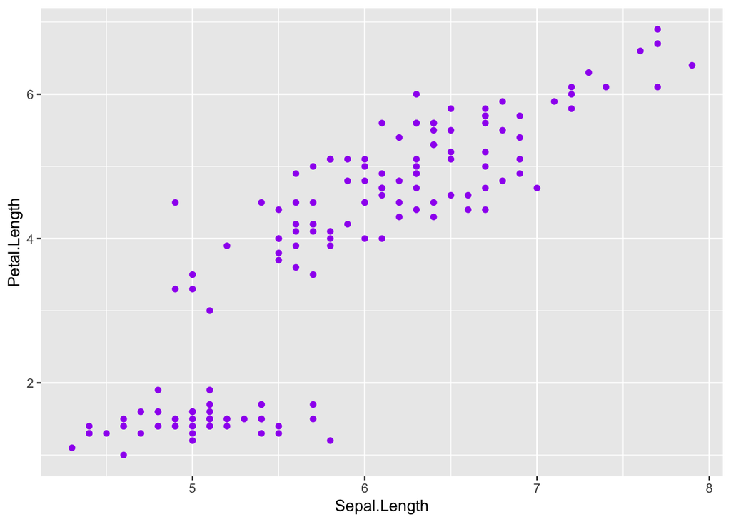

```r
# Mapping 2
# It is important to remember the difference between mapping a colour and setting a colour
# This is how you set the colour on a plot
ggplot(data = iris) +
 geom_point(mapping = aes(x = Sepal.Length,
                          y = Petal.Length),
            colour = "purple")
```

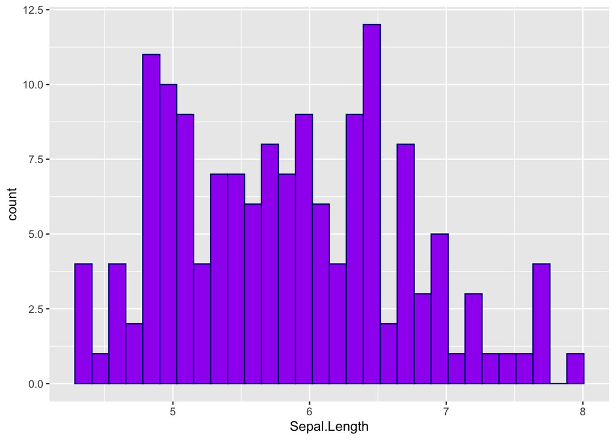

```r
# Mapping 3
# Some geometries use fill to set the colour inside the graphic
ggplot(data = iris) +
 geom_histogram(mapping = aes(x = Sepal.Length),
            fill = "purple",
            colour = "navy")
```

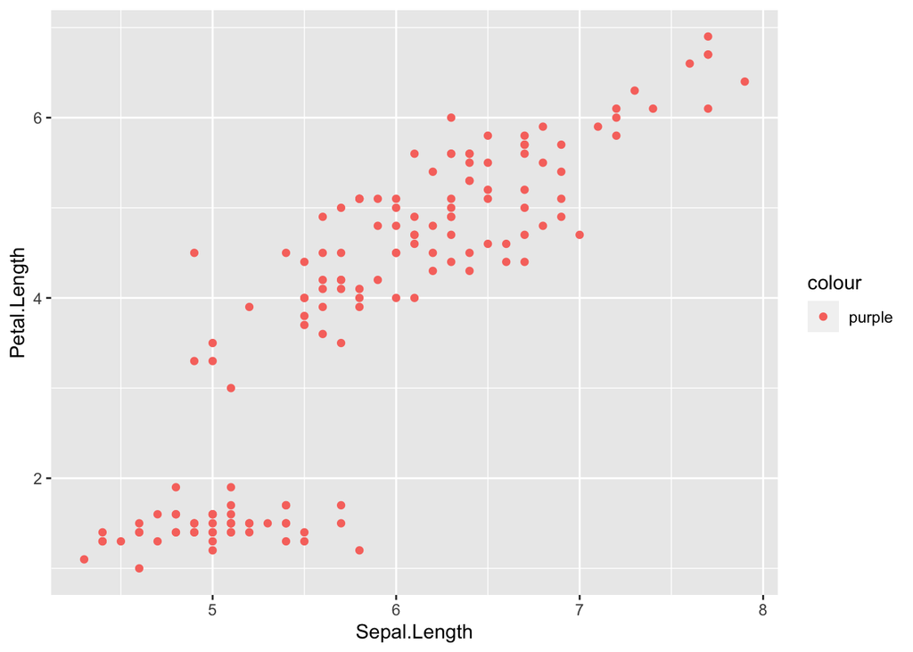

```r
# Mapping 4
# This is how **NOT** to set the colour of a plot
# Do you know what is happening here?
ggplot(data = iris) +
 geom_point(mapping = aes(x = Sepal.Length,
                          y = Petal.Length,
                          colour = "purple"))
```

> *Remember:* If you want to map a colour from the data put it in `aes()` if you want to set a colour or size put it outside `aes()`.

### Exercises

Update the code to make the points larger purple triangles and slightly transparent.

```r
ggplot(iris) +
  geom_point(aes(x = Sepal.Length, y = Petal.Length))
```

Colour the two distributions in the histogram with different colours.

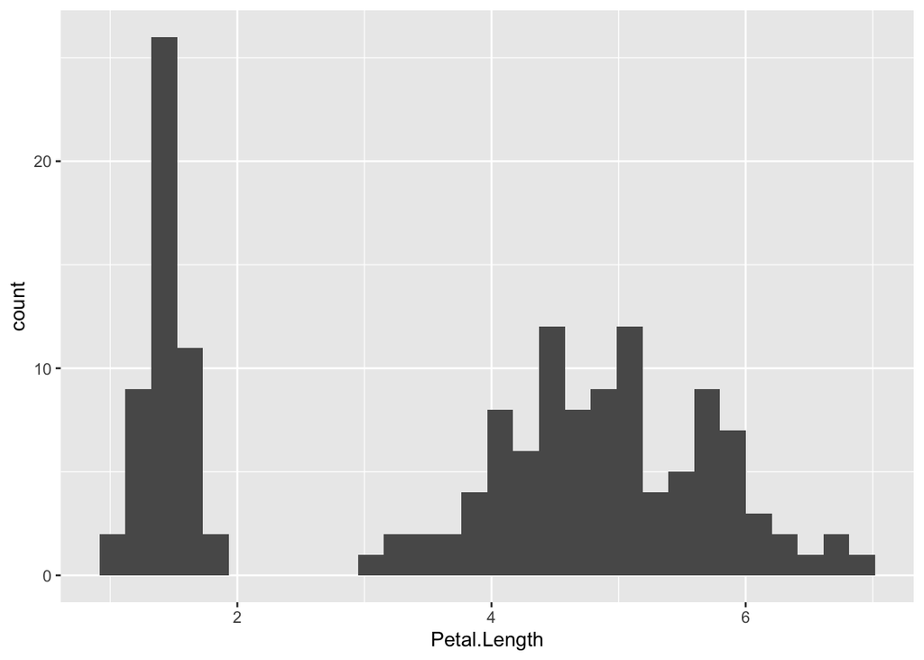

```r
ggplot(iris) +
  geom_histogram(aes(x = Petal.Length))
```

### The grammar of graphics: Geometries

##### data / mapping / statistics / scales / **GEOMETRIES** / facets / coordinates / theme

- Geometries take the scale values and plots them according to a specific geometry
- The same data input can have a vast array of geometric representations
- For example the scatter plot and line plot can take the same the data but you will get a different output
- Geometries can be stacked on top of each other based on your code order

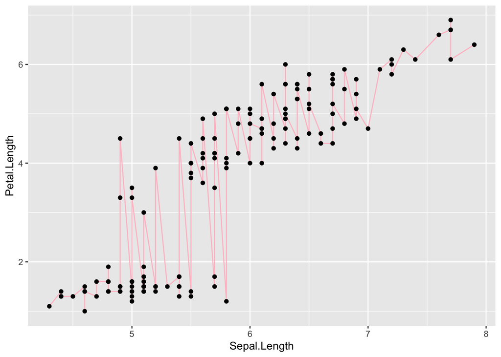

```r
# Geometries 1
# In this example you can see that the points sit on top of the line
ggplot(data = iris) +
  geom_line(mapping = aes(x = Sepal.Length, y = Petal.Length), colour = "pink") +
  geom_point(mapping = aes(x = Sepal.Length, y = Petal.Length))
```

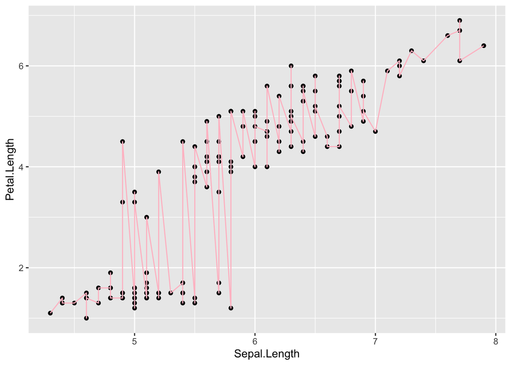

```r
# In this example the line sits on top of the points
# This is due to the order of the geometries
ggplot(data = iris) +
  geom_point(mapping = aes(x = Sepal.Length, y = Petal.Length)) +
  geom_line(mapping = aes(x = Sepal.Length, y = Petal.Length), colour = "pink")
```

### The grammar of graphics: Statistics

##### data / mapping / **STATISTICS** / scales / geometries / facets / coordinates / theme

The statistics part refers to the calculations that are happening to transform your raw data into the values we want to display on the plot. For example, a bar chart calculates counts and box plots calculate a range of distribution values. - Every geometry has a default statistic. - Every statistic has a default geometry - Both can be used but people are used to thinking in geometries. You visualise bars rather than counts. - You can access the values generated through the stat by using the `after_stat()` function.

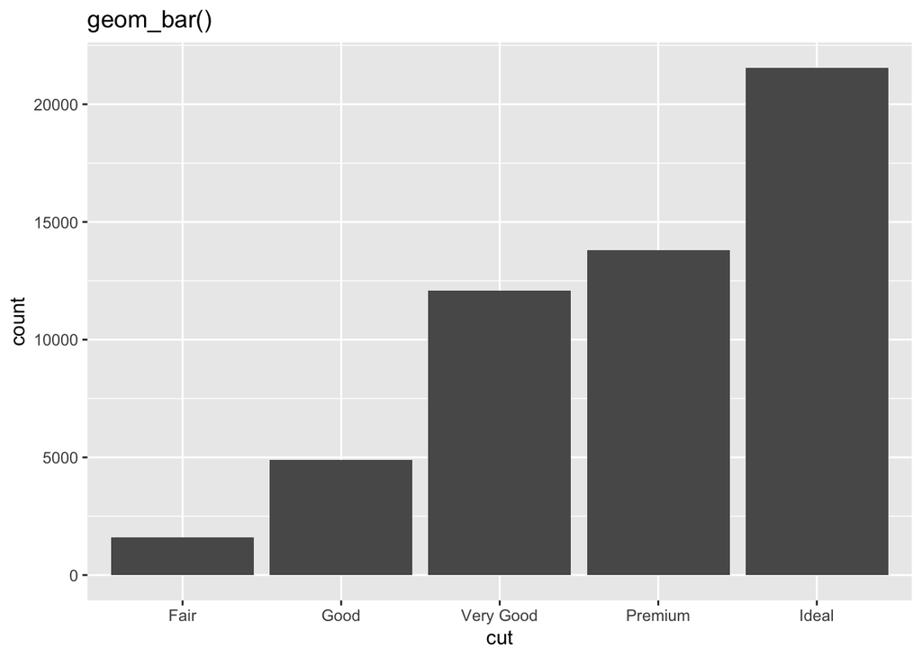

```r
#geom_bar() uses stat_count() by default
ggplot(data = diamonds) +
  geom_bar(mapping = aes(x=cut)) +
  ggtitle("geom_bar()")
```

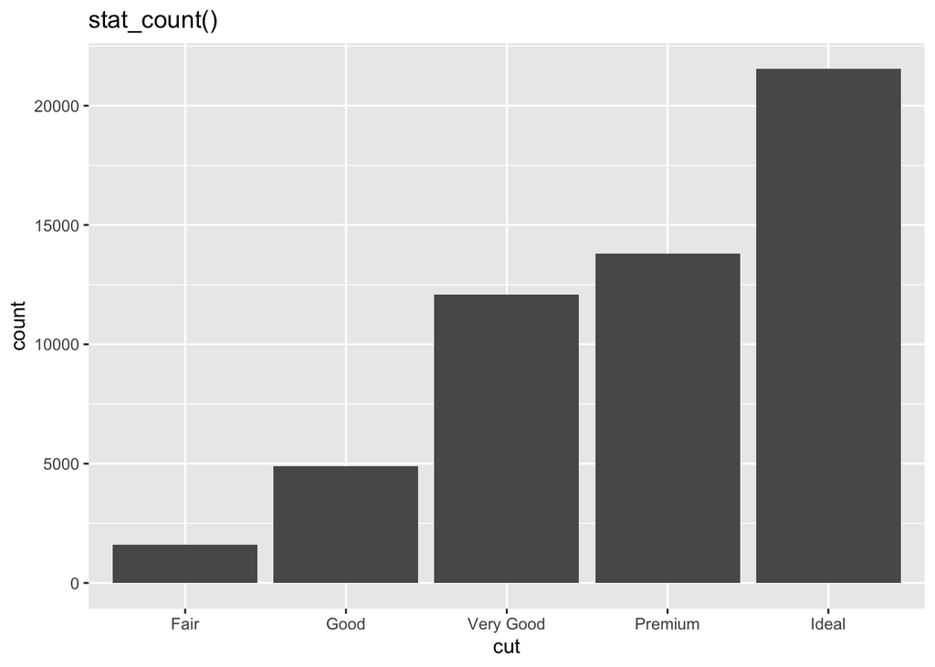

```r
# we get the same plot because the default geom for stat_count() is geom_bar()
ggplot(data = diamonds) +
  stat_count(mapping = aes(x=cut)) +
  ggtitle("stat_count()")
```

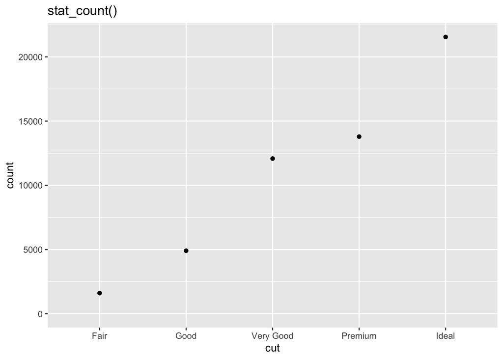

```r
# but you can update the geom to something else - normally you wouldn't want to override this.
ggplot(data = diamonds) +
  stat_count(mapping = aes(x=cut), geom = 'point') +
  ggtitle("stat_count()")
```

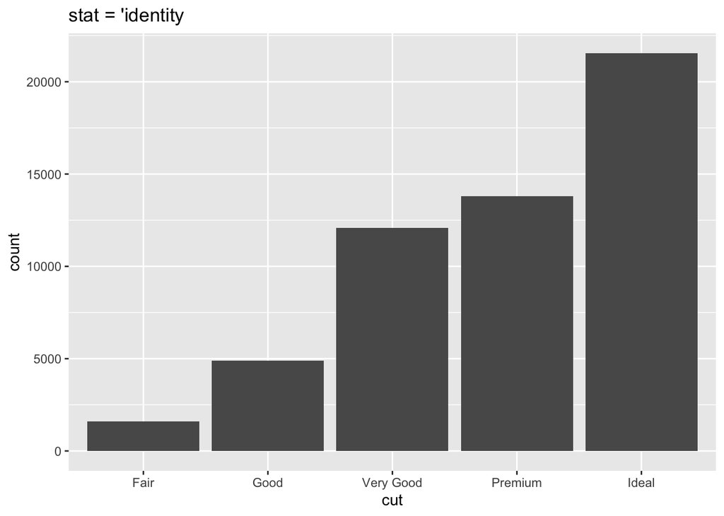

```r
# You can calculate the statistics yourself and plot the results
diamonds_counted_by_cut = diamonds %>%
  group_by(cut) %>%
  summarise(count = n())

ggplot(data = diamonds_counted_by_cut) +
  geom_bar(mapping = aes(x=cut, y=count),
           stat = 'identity') + # identity stat doesn't compute anything
  ggtitle("stat = 'identity")
```

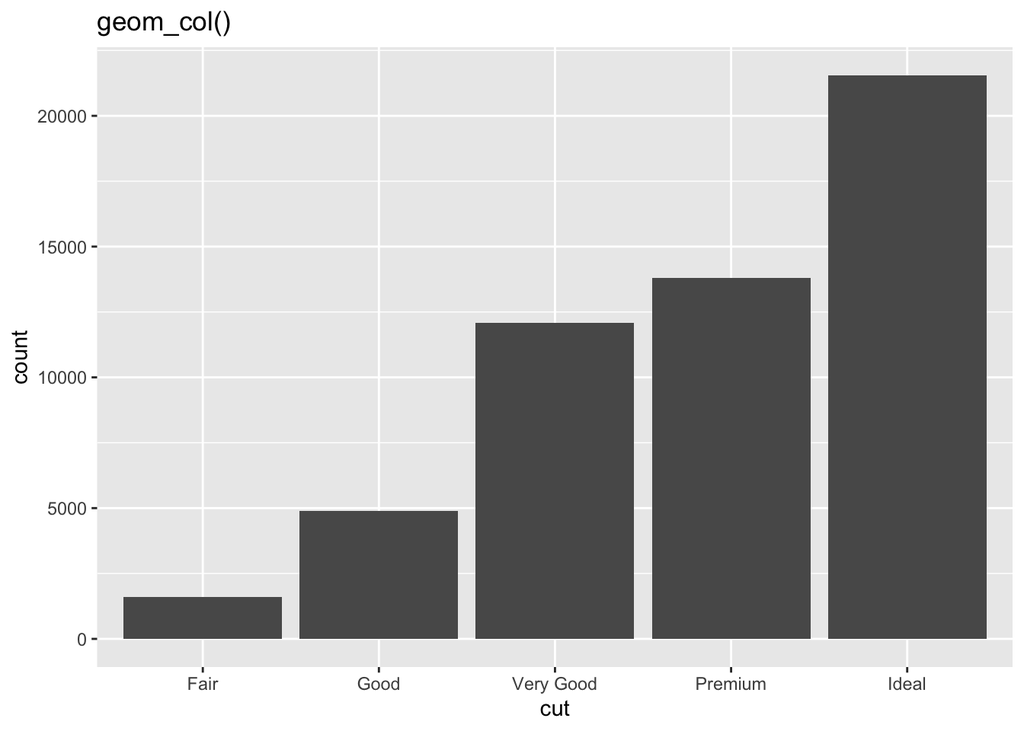

```r
# ggplot2 provide geometries for the most frequently used combinations of statistics and geometries. For example, geom_col() is geom_bar() with the stat set to "identity".
ggplot(data = diamonds_counted_by_cut) +
  geom_col(mapping = aes(x=cut, y=count)) +
  ggtitle("geom_col()")
```

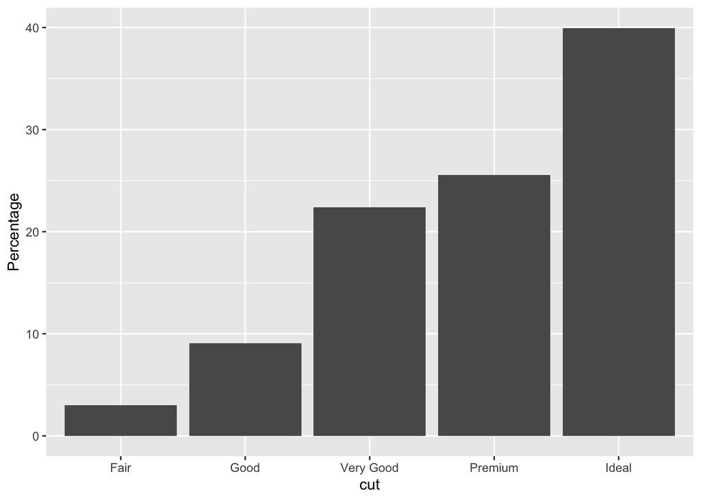

```r
# You can access the values generated through the stat by using the after_stat() function.
# Here we will change the counts to percentages
#geom_bar() uses stat_count() by default
ggplot(data = diamonds) +
  geom_bar(mapping =
             aes(
               x = cut,
               y = after_stat(100 * count / sum(count))
               )
           ) + labs(y = "Percentage")
```

```r
# Computed variables are provided in the stat_ documentation
# ?stat_count
# ?stat_density
# ?stat_boxplot
```